# Aplicación del Algoritmo de Lobo Gris Discreto (DGWO) en la Distribución de Instalaciones con Áreas Desiguales (UAFLP)

El presente notebook contiene el código en forma de clases para la aplicación del DGWO en la Distribución de Instalaciones con Áreas Desiguales (UAFLP):

## 1. Clase `ModeloUAFLP`

Clase para el modelo UAFLP:

1. Clase `ModeloUAFLP`: Contiene la información de entrada y los métodos del modelo UAFLP:
   - `obtener_datos`: Método para leer y guardar la información de entrada del modelo UAFLP desde un `archivo_datos`.
   - `decodificar_solucion`: Método usado para convertir una solución de la forma `np.array([[1, 2, 3...], [1, 0, 1...]])` en un plano de bloque de planta con la información de los lados y centroides de los departamentos. Incluye los siguientes métodos:
     - `identificar_bahias`: Se usa para identificar el número de bahías en una solución de la forma `np.array([[1, 2, 3...], [1, 0, 1...]])` y los departamentos que se encuentran dentro de cada bahía.
     - `calcular_lados_centros`: Se usa para calcular y guardar la información de las dimensiones de ancho y largo de cada departamento dentro de cada bahía, así como las coordenadas de los centroides (punto medio) de cada departamento.
   - `dibujar_layout`: Método para mostrar el plano de bloque de la planta que representa una solución de la forma `np.array([[1, 2, 3...], [1, 0, 1...]])`.
   - `calcular_fitness`: Método para calcular la función fitness (o de ajuste) dada para una solución de la forma `np.array([[1, 2, 3...], [1, 0, 1...]])`. La función fitness está dada por el costo total de manejo de materiales entre departamentos + una penalización por cada departamento que infrinja el requerimiento de tasa de aspecto máxima. Incluye los siguientes métodos:
     - `decodificar_solucion`: Descrito anteriormente.
     - `calcular_distancias`: Calcula la distancia rectilínea en $x$ y $y$ entre cada par de departamentos y las guarda en un `np.array`.
     - `calcular_mhc`: Calcula el costo total de manejo de materiales entre departamentos como la suma de la multiplicación entre las distancias rectilíneas, el flujo de materiales y el costo unitario de manejo entre todos los departamentos.

```python
import os
import sys
import numpy as np
import matplotlib.pyplot as plt

class ModeloUAFLP:

    # Constructor de la clase (argumentos requeridos para crear la clase)
    def __init__(self, n_dptos:int=None, areas_dptos:np.ndarray=None, flujo_materiales:np.ndarray=None,
                lados_instalacion:np.ndarray=None, tasa_aspecto_max:int=None, costo_manejo_unit:float=None,
                nombres_dptos:list=None, mejor_valor:float=None, archivo_datos:str=None) -> None:

        if archivo_datos == None:
            self.n_dptos = n_dptos
            self.departamentos = np.arange(1, self.n_dptos + 1)
            self.areas_dptos = areas_dptos
            self.flujo_materiales = flujo_materiales
            self.lados_instalacion = lados_instalacion # ancho, largo
            self.tasa_aspecto_max = tasa_aspecto_max
            self.nombres_dptos = nombres_dptos
            self.mejor_val = mejor_valor
            self.costo_manejo_unit = costo_manejo_unit

            # Definir matriz de costo de manejo unitario
            if self.costo_manejo_unit == None:
                self.matriz_costos_dptos = np.ones((self.n_dptos, self.n_dptos))
            else:
                self.matriz_costos_dptos = np.full((self.n_dptos, self.n_dptos), self.costo_manejo_unit)
        else: # Extraer datos de archivo de datos
            self.obtener_datos(arch_datos=archivo_datos)

    # Método para leer archivo de datos
    def obtener_datos(self, arch_datos:str):

        # Cambiar el directorio
        path = os.path.dirname(os.path.realpath(__file__)) + '\\uaflp-instances'

        try:
            os.chdir(path)
        except FileNotFoundError:
            print(f'Directory: {path} does not exist')
            sys.exit()
        except NotADirectoryError:
            print(f'{path} is not a directory')
            sys.exit()

        # Abrir el archivo de datos
        with open(arch_datos) as f:
            lines = f.readlines()

        # Leer cada linea del archivo
        pr_linea = lines[0].split() # [n_dptos, ancho_inst, largo_inst, tasa_asp, costo_unit, mejor_val]
        seg_linea = lines[1].split() # [areas_dptos 1,..., n]
        ter_linea = lines[2].split() # [nombres_dptos 1,..., n] o ['None']
        fl_mats = [] # lista de listas flujos de materials
        for l in lines[3:]:
            ln = [float(x) for x in l.split()]
            fl_mats.append(ln)

        # Guardar los parametros del modelo UAFLP
        self.n_dptos = int(pr_linea[0])
        self.departamentos = np.arange(1, self.n_dptos + 1)
        self.lados_instalacion = np.array([float(x) for x in pr_linea[1:3]])
        self.tasa_aspecto_max = int(pr_linea[3])
        self.costo_manejo_unit = float(pr_linea[4])
        self.matriz_costos_dptos = np.full((self.n_dptos, self.n_dptos), self.costo_manejo_unit)
        self.mejor_val = float(pr_linea[-1])
        self.areas_dptos = np.array([float(x) for x in seg_linea])

        if len(ter_linea) > 1:
            self.nombres_dptos = [x for x in ter_linea]
        else:
            self.nombres_dptos = None

        self.flujo_materiales = np.array(fl_mats)


    # Método para decodificar la solución
    def decodificar_solucion(self, solucion:np.ndarray):
        self.identificar_bahias(solucion)
        self.calcular_lados_centros()

    # Identificar bahías
    def identificar_bahias(self, solucion):
        self.bahias = []
        dpts_bahias = []

        for ind, bah in enumerate(solucion[1]):
            dpto = solucion[0, ind] # Identificar dpto en posicion

            if ind == 0 or bah == 0:
                dpts_bahias.append(dpto) # Añadir dptos en bahía
                if bah == 1:
                    self.bahias.append(dpts_bahias) # Añadir bahía a bahías
                    dpts_bahias = []
            elif bah == 1:
                dpts_bahias.append(dpto) # Añadir dptos en bahía
                self.bahias.append(dpts_bahias) # Añadir bahía a bahías
                dpts_bahias = []

    # Calcular dimensiones de lados y centroides de los departamentos
    def calcular_lados_centros(self):
        self.centroides_dptos = [0] * self.n_dptos
        self.lados_dptos = [0] * self.n_dptos

        contador_ancho = 0
        for bah in self.bahias:

            area_bahia = 0
            for dpto in bah:
                area_bahia += self.areas_dptos[dpto-1] # area bahia = suma(areas dptos en bahia)

            ancho_bahia = area_bahia / self.lados_instalacion[1] # ancho bahia = area de bahia / largo de instalacion

            contador_largo = 0
            for dpto in bah:
                largo_dpto = self.areas_dptos[dpto-1] / ancho_bahia # largo dpto = area dpto / ancho bahia
                self.lados_dptos[dpto-1] = [ancho_bahia, largo_dpto] # Nota: ancho bahia == ancho dpto en bahia
                centro_x = contador_ancho + ancho_bahia / 2
                centro_y = contador_largo + largo_dpto / 2
                self.centroides_dptos[dpto-1] = [centro_x, centro_y]
                contador_largo += largo_dpto

            contador_ancho += ancho_bahia

    # Dibujar layout de planta de la solucion
    def dibujar_layout(self, solucion:np.ndarray):
        if self.nombres_dptos == None:
            self.nombres_dptos = [f'Dpto {d}' for d in self.departamentos]

        self.decodificar_solucion(solucion)

        if self.lados_instalacion[0] > self.lados_instalacion[1]:
            fig = plt.figure(dpi=300, figsize=(6, 4))
        else:
            fig = plt.figure(dpi=300, figsize=(4, 6))

        plt.rcParams.update({'font.size': 6})
        ax = fig.add_subplot(111)
        ax.set_xlim([0, self.lados_instalacion[0]])
        ax.set_ylim([0, self.lados_instalacion[1]])
        ax.set_xticks([0, self.lados_instalacion[0]])
        ax.set_yticks([0, self.lados_instalacion[1]])

        esq_x = 0
        for bah in self.bahias:

            esq_y = 0
            for dpt in bah:
                rect = plt.Rectangle((esq_x, esq_y), width=self.lados_dptos[dpt-1][0],
                                     height=self.lados_dptos[dpt-1][1], facecolor='white',
                                     edgecolor='black')
                plt.text(self.centroides_dptos[dpt-1][0], self.centroides_dptos[dpt-1][1],
                         f'{self.nombres_dptos[dpt-1]}', horizontalalignment='center',
                         verticalalignment='top')
                plt.plot(self.centroides_dptos[dpt-1][0], self.centroides_dptos[dpt-1][1],
                         color='black', marker=None, markersize=2)
                ax.add_patch(rect)

                esq_y += self.lados_dptos[dpt-1][1]

            esq_x += self.lados_dptos[dpt-1][0]

        plt.show()

    # Calcular la función fitness
    def calcular_fitness(self, solucion:np.ndarray):
        self.decodificar_solucion(solucion)
        self.calcular_distancias()
        self.calcular_mhc()

        k = 3

        contador_no_factibles = 0
        for i in solucion[0]:
            tasa_aspecto_dpto = max(self.lados_dptos[i-1][0], self.lados_dptos[i-1][1]) / min(self.lados_dptos[i-1][0], self.lados_dptos[i-1][1])

            if tasa_aspecto_dpto > self.tasa_aspecto_max:
                contador_no_factibles += 1

        fitness = self.mhc + self.mhc * (contador_no_factibles ** k)

        return round(fitness, ndigits=2)

    # Calcular las distancias rectilíneas entre departamentos
    def calcular_distancias(self):
        self.distancias_dptos = np.zeros((self.n_dptos, self.n_dptos))

        for i in self.departamentos:
            for j in self.departamentos[i:]:
                dist_rectil_x = np.abs(self.centroides_dptos[i-1][0] - self.centroides_dptos[j-1][0])
                dist_rectil_y = np.abs(self.centroides_dptos[i-1][1] - self.centroides_dptos[j-1][1])

                self.distancias_dptos[j-1, i-1] = dist_rectil_x + dist_rectil_y

    # Calcular el costo total de manejo de materiales entre departamentos
    def calcular_mhc(self):

        self.mhc = np.sum(self.matriz_costos_dptos * self.distancias_dptos * self.flujo_materiales)
```

## 2. Clase `AlgLoboGris`

Clase para el algoritmo DGWO, heredando los métodos de la clase del modelo UAFLP:

2. Clase `AlgLoboGris`: Contiene los parámetros y los métodos del Algoritmo DGWO:
   - `optimizacion_lobo_gris`: Incluye todas las operaciones del Algoritmo DGWO, desde la inicialización de los parámetros del algoritmo hasta las operaciones de generación de manada, identificación de líderes, búsqueda de la presa y ataque de la presa. Retorna las mejores soluciones de cada iteración en un tiempo dado. Incluye los siguientes métodos:
     - `generar_manada`: Método utilizado para generar un número de soluciones dado por el parámetro `tam_manada`. Estas soluciones son guardadas en dos listas. Una que incluye las soluciones de la forma `np.array([[1, 2, 3...], [1, 0, 1...]])` y otra que incluye el valor de la función fitness respectiva.
     - `identificar_lideres`: Método utilizado para las mejores soluciones en la manada de soluciones que se generó anteriormente. El número de líderes está dado por el parámetro `n_lideres`, el cual solo puede tener el valor de $1$ o $3$, y en donde la mejor solución conocida será denominado **lobo alfa**, seguido de los **lobos beta y delta**, si es el caso. Los lobos líderes se eliminan de la manada y se guardan en dos listas aparte, una que incluye las soluciones de la forma `np.array([[1, 2, 3...], [1, 0, 1...]])` y otra que incluye el valor de su función fitness respectiva.
     - `buscar_presa`: Este método se usa para representar el comportamiento de búsqueda de la presa, es decir de la mejor solución. Consiste en los siguientes pasos:
       - Calcular el tamaño de movimiento, dado por el parámetro `theta_1`, que es el número de elementos que se moverán en la solución del tipo `np.array([[1, 2, 3...], [1, 0, 1...]])`
       - Por cada lobo de la manada, se toma su solución del tipo `np.array([[1, 2, 3...], [1, 0, 1...]])` y se realiza un movimiento aleatorio dado por el tamaño de movimiento calculado en el paso anterior. Esta operación se realiza a través del método `realizar_movimiento`.
       - Una vez realizado el movimiento, la nueva solución resultante es evaluada en su función fitness y se compara con respecto al *lobo alfa* y a la solución actual en la manada.
       - En caso de que la nueva solución sea mejor en su valor fitness al *lobo alfa*, se reemplaza el lobo alfa en la lista de líderes, el *lobo delta* o el anterior lobo alfa son relegados a la manada y la operación de búsqueda de la presa se detiene para iniciar el comportamiento de ataque. Esta operación se realiza a través del método `insertar_nuevo_lider`.
       - En caso de que la nueva solución solo sea mejor que la solución actual en la manada, simplemente se reemplaza en la manada.
       - En caso de que la nueva solución no sea mejor que la solución actual en la manada, se rechaza y se continúa con el siguiente miembro de la manada.
     - `atacar_presa`: Este método busca representar el comportamiento de ataque de la presa, es decir, acercarse a la mejor solución conocida, la cual se ha guardado en la solución de el (los) lobo(s) líder(es). Consiste en los siguientes pasos:
       - Calcular la distancia mínima a la cual las soluciones representadas por los lobos de la manada deben acercarse con respecto a la solución guardada en los lobos líderes. Esta está dada por el parámetro `theta_2`.
       - Por cada lobo de la manada, identificar el lobo líder con respecto al cual se va a reducir la distancia de la solución. Esta operación está dada por el parámetro `theta_3`, que representa la influencia del *lobo alfa* o de la mejor solución conocida.
         - En caso de que el parámetro `n_lideres` sea igual a $1$, solo se eligirá el *lobo alfa*.
         - En caso de que el parámetro `n_lideres` sea igual a $3$, el parámetro `theta_3` representa la probabilidad de que sea elegido el *lobo alfa*. Sin embargo, los lobos *beta y delta* pueden ser elegidos con probabilidad $(1 - \theta_3)/2$.
       - Calcular la distancia entre la solución del lobo de la manada y la del lobo líder seleccionado. La distancia es el número de elementos que son diferentes entre las soluciones de tipo `np.array([[1, 2, 3...], [1, 0, 1...]])`. Por ejemplo, si el elemento 1 de la solución de la manada es igual a $5$ y el elemento 1 de la solución del lobo líder es diferente a $5$, se suma $1$ a la distancia entre soluciones. Esta operación se realiza a través del método `calcular_dist_lider`.
       - Reducir la distancia entre la solución del lobo de la manada y la del lobo líder seleccionado. Para ello, se iguala cada elemento de la solución del lobo de la manada con respecto al valor de cada elemento en la solución del lobo líder hasta que la distancia entre soluciones es reducida a la distancia mínima calculada en el primer paso. Esta operación se realiza a través de los métodos `reducir_dist_dptos` y `reducir_dist_bahias`.
       - Finalmente, se evalúa el valor de la función fitness de la nueva solución obtenida y se compara (y reemplaza, si es el caso) con respecto al lobo alfa y a la solución actual de la manada.

```python
import numpy as np
from copy import deepcopy
from time import time
from uaflp import ModeloUAFLP

class AlgLoboGris(ModeloUAFLP):

    # Constructor de la clase (hereda las caracteristicas de la clase ModeloUAFLP)
    def __init__(self, n_dptos: int = None, areas_dptos: np.ndarray = None, flujo_materiales: np.ndarray = None, lados_instalacion: np.ndarray = None, tasa_aspecto_max: int = None, costo_manejo_unit: float = None, nombres_dptos: list = None, mejor_valor: float = None, archivo_datos: str = None) -> None:
        super().__init__(n_dptos, areas_dptos, flujo_materiales, lados_instalacion, tasa_aspecto_max, costo_manejo_unit, nombres_dptos, mejor_valor, archivo_datos)

    # Correr algoritmo de lobo gris
    def optimizacion_lobo_gris(self, tam_manada:int, n_lideres:int, theta_1:float, theta_2:float, theta_3:float=1, tiempo_lim:int=600):

        if tam_manada not in range(n_lideres + 1, 16):
            raise ValueError('Parameter value tam_manada should be greater than n_lideres and lower than 15')

        if n_lideres not in {1, 3}:
            raise ValueError('Parameter value n_lideres should be equal to 1 or equal to 3')

        if theta_1 <= 0 or theta_1 >= 1 or theta_2 <= 0 or theta_2 >= 1 or theta_3 <= 0 or theta_3 > 1:
            raise ValueError(f'Parameter values theta_1, theta_2 and theta_3 should be greater than 0 and lower than 1: {[theta_1, theta_2, theta_3]}')

        if n_lideres == 1:
            theta_3 = 1
            print('Since n_lideres parameter value is 1, the parameter value for theta_3 is set to 1')

        timeout = time() + tiempo_lim
        lobos_sols = []
        fit_sols = []

        self.generar_manada(tam_manada)
        self.identificar_lideres(n_lideres)
        while time() < timeout:

            self.buscar_presa(theta_1)
            self.atacar_presa(n_lideres, theta_2, theta_3)

            lobos_sols.append(self.lobos_lideres[0])
            fit_sols.append(self.fit_lideres[0])

        return {'sols_uaflp': lobos_sols, 'vals_fitness': fit_sols}

    # Inicializar poblacion de la manada
    def generar_manada(self, tam_manada):

        self.manada = [0] * tam_manada
        self.fit_manada = [0] * tam_manada

        for lobo_ind in range(tam_manada):
            lobo_dpts = list(np.random.permutation(self.departamentos))
            lobo_bahs = list(np.random.randint(0, 2, self.n_dptos - 1)) + [1]
            self.manada[lobo_ind] = np.array([lobo_dpts, lobo_bahs])
            self.fit_manada[lobo_ind] = self.calcular_fitness(self.manada[lobo_ind])

    # Identificar lobos lideres ([alpha]) si n_lideres = 1, ([alpha, beta, delta]) si n_lideres = 3
    def identificar_lideres(self, n_lideres):

        self.lobos_lideres = [0] * n_lideres
        self.fit_lideres = [0] * n_lideres

        for ind in range(n_lideres):
            p_min = np.argmin(self.fit_manada)
            self.lobos_lideres[ind] = self.manada[p_min]
            self.fit_lideres[ind] = self.fit_manada[p_min]
            self.manada.pop(p_min)
            self.fit_manada.pop(p_min)

    # Ejecutar comportamiento de busqueda de la presa
    def buscar_presa(self, theta_1):

        tam_movimiento = np.floor(self.n_dptos * theta_1).astype(int)

        for ind, lobo in enumerate(self.manada):

            lobo_dp = deepcopy(lobo[0])
            lobo_bh = deepcopy(lobo[1])

            # Realizar movimiento en elementos de lobos
            lobo_dp = self.realizar_movimiento(lobo_dp, tam_movimiento)
            lobo_bh = self.realizar_movimiento(lobo_bh, tam_movimiento)

            if lobo_bh[-1] != 1:
                lobo_bh[-1] = 1

            # Calcular funcion fitness del nuevo lobo
            nuevo_lobo = np.array([list(lobo_dp), list(lobo_bh)])
            fit_nuevo_lobo = self.calcular_fitness(nuevo_lobo)

            # Comparar y reemplazar (si aplica) nuevo lobo generado
            if fit_nuevo_lobo < self.fit_lideres[0]:

                self.insertar_nuevo_lider(nuevo_lobo, fit_nuevo_lobo, ind)
                break # Romper busqueda para iniciar ataque

            elif fit_nuevo_lobo < self.fit_manada[ind]:

                # Reemplazar nuevo lobo en manada
                self.manada[ind] = nuevo_lobo
                self.fit_manada[ind] = fit_nuevo_lobo

    # Ejecutar comportamiento de ataque a la presa
    def atacar_presa(self, n_lideres, theta_2, theta_3=None):

        da = np.floor(self.n_dptos * theta_2)

        for ind_md, lobo in enumerate(self.manada):

            nuevo_lobo = deepcopy(lobo)
            lider = None
            if n_lideres == 1:
                lider = self.lobos_lideres[0]
            else:
                rand = np.random.random()
                if rand < theta_3:
                    lider = self.lobos_lideres[0]
                elif rand < (theta_3 + (1 - theta_3)/2):
                    lider = self.lobos_lideres[1]
                else:
                    lider = self.lobos_lideres[2]

            # Calcular y reducir distancia con el lider para elemento con dptos
            dist_dptos = self.calcular_dist_lider(nuevo_lobo[0], lider[0])

            ind_dp = 0
            while dist_dptos > da:

                nuevo_lobo[0] = self.reducir_dist_dptos(nuevo_lobo[0], lider[0], ind_dp)
                dist_dptos = self.calcular_dist_lider(nuevo_lobo[0], lider[0])
                ind_dp += 1

            # Calcular y reducir distancia con el lider para elemento de bahias
            dist_bahias = self.calcular_dist_lider(nuevo_lobo[1], lider[1])

            ind_bh = 0
            while dist_bahias > da:

                nuevo_lobo[1] = self.reducir_dist_bahias(nuevo_lobo[1], lider[1], ind_bh)
                dist_bahias = self.calcular_dist_lider(nuevo_lobo[1], lider[1])
                ind_bh += 1

            fit_nuevo_lobo = self.calcular_fitness(nuevo_lobo)

            # Comparar y reemplazar (si aplica) nuevo lobo generado
            if fit_nuevo_lobo < self.fit_lideres[0]:

                 self.insertar_nuevo_lider(nuevo_lobo, fit_nuevo_lobo, ind_md)

            elif fit_nuevo_lobo < self.fit_manada[ind_md]:

                # Reemplazar nuevo lobo en manada
                self.manada[ind_md] = nuevo_lobo
                self.fit_manada[ind_md] = fit_nuevo_lobo

    # Metodo para realizar movimiento en elemento de lobos
    def realizar_movimiento(self, elem_lobo, tam_movimiento):

        pos_inicio, pos_fin = np.random.randint(0, self.n_dptos - tam_movimiento + 1, 2)
        pos_movimiento = np.arange(pos_inicio, pos_inicio + tam_movimiento)
        movimiento = elem_lobo[pos_movimiento]
        elem_lobo = np.delete(elem_lobo, pos_movimiento)
        elem_lobo = np.insert(elem_lobo, pos_fin, movimiento)

        return elem_lobo

    # Metodo para reemplazar nuevo lider en lideres y desplazar lobo delta a manada
    def insertar_nuevo_lider(self, nuevo_lobo, fit_nuevo_lobo, ind_manada):

        # Agregar nuevo alpha a los lideres
        self.lobos_lideres.insert(0, nuevo_lobo)
        self.fit_lideres.insert(0, fit_nuevo_lobo)

        # Desplazar antiguo lobo delta a la manada
        self.manada[ind_manada] = self.lobos_lideres[-1]
        self.fit_manada[ind_manada] = self.fit_lideres[-1]

        # Eliminar antiguo lobo delta de los lideres
        self.lobos_lideres.pop()
        self.fit_lideres.pop()

    # Metodo para calcular distancia entre lobo en manada y lobo lider
    def calcular_dist_lider(self, elem_lobo, elem_lider):

        distancia = 0
        for ind in range(len(elem_lider)):
            if elem_lobo[ind] != elem_lider[ind]:
                distancia += 1

        return distancia

    # Metodo para reducir la distancia entre el lobo en manada y lobo lider (para elemento con dptos)
    def reducir_dist_dptos(self, elem_lobo, elem_lider, ind_actual):

        dpto_lobo = elem_lobo[ind_actual]
        dpto_lider = elem_lider[ind_actual]
        if dpto_lobo != dpto_lider:
            pos_cambio = np.where(elem_lobo == dpto_lider)[0]
            elem_lobo[ind_actual] = dpto_lider
            elem_lobo[pos_cambio] = dpto_lobo

        return elem_lobo

    # Metodo para reducir la distancia entre el lobo en manada y lobo lider (para elemento con bahias)
    def reducir_dist_bahias(self, elem_lobo, elem_lider, ind_actual):

        if elem_lobo[ind_actual] != elem_lider[ind_actual]:
            elem_lobo[ind_actual] = elem_lider[ind_actual]

        return elem_lobo
```

## 3. Celda principal para la aplicación del algoritmo DGWO

Celda para la aplicación de la clase `AlgLoboGris` al modelo `ModeloUAFLP`.

```python
# Valores de los parámetros
val_mnd = 10 # Posibles valores: [6, 8, 10, 12, 15]
val_ld = 3 # Posibles valores: [1, 3]
val_t1 = 0.4 # Posibles valores: [0.2, 0.4, 0.6, 0.8]
val_t2 = 0.4 # Posibles valores: [0.2, 0.4, 0.6, 0.8]
val_t3 = 0.4 # Posibles valores: [0.2, 0.4, 0.6, 0.8]
tiempo_lim = 300 # en segundos
n_rondas = 10 # Numero de veces que el algoritmo corre
```

```python
import pandas as pd

# Identificar el archivo y leer las instancias de datos
with open('./uaflp-instances/uaflp_instances.txt') as f:
    insts = f.readlines()

# Crear diccionario para guardar los resultados
resultados = {'inst': [],
              'n_dptos': [],
              'mejor_val': []}

# Guardar los datos principales del problema
for ln in insts:

    inst = ln.split()[0]

    prob = ModeloUAFLP(archivo_datos=inst)

    resultados['inst'].append(inst)
    resultados['n_dptos'].append(prob.n_dptos)
    resultados['mejor_val'].append(prob.mejor_val)

rond = 0
while rond < n_rondas:

    resultados[f'UB_{rond}'] = []
    resultados[f'gap_{rond}'] = []
    resultados[f'sol_{rond}'] = []

    for inst in resultados['inst']:

        dgwo = AlgLoboGris(archivo_datos=inst)

        res_dgwo = dgwo.optimizacion_lobo_gris(tam_manada=val_mnd, n_lideres=val_ld, theta_1=val_t1,
                                            theta_2=val_t2, theta_3=val_t3, tiempo_lim=tiempo_lim)

        uaflp_ub = res_dgwo['vals_fitness'][-1]
        gap = (uaflp_ub - dgwo.mejor_val)/dgwo.mejor_val
        uaflp_sol = res_dgwo['sols_uaflp'][-1]

        resultados[f'UB_{rond}'].append(uaflp_ub)
        resultados[f'gap_{rond}'].append(gap)
        resultados[f'sol_{rond}'].append(uaflp_sol)

        print(f'El algoritmo finaliza la ronda {rond} para la inst {inst} con UB = {uaflp_ub}')

    rond += 1

df = pd.DataFrame(resultados)
df.set_index('inst', inplace=True)

df.to_excel('test_dgwo.xlsx')
```

```
El algoritmo finaliza la ronda 0 para la inst inst_O7.txt con UB = 142.25
El algoritmo finaliza la ronda 0 para la inst inst_O8.txt con UB = 358.67
El algoritmo finaliza la ronda 0 para la inst inst_O9.txt con UB = 284.31
El algoritmo finaliza la ronda 0 para la inst inst_vC10R-a.txt con UB = 26326.75
El algoritmo finaliza la ronda 0 para la inst inst_garment11.txt con UB = 11730.2
El algoritmo finaliza la ronda 0 para la inst inst_MB12.txt con UB = 810.3
El algoritmo finaliza la ronda 1 para la inst inst_O7.txt con UB = 142.25
El algoritmo finaliza la ronda 1 para la inst inst_O8.txt con UB = 271.86
El algoritmo finaliza la ronda 1 para la inst inst_O9.txt con UB = 257.59
El algoritmo finaliza la ronda 1 para la inst inst_vC10R-a.txt con UB = 28906.35
El algoritmo finaliza la ronda 1 para la inst inst_garment11.txt con UB = 12871.35
El algoritmo finaliza la ronda 1 para la inst inst_MB12.txt con UB = 181.56
El algoritmo finaliza la ronda 2 para la inst inst_O7.txt con UB = 137.8
El algoritmo finaliza la ronda 2 para la inst inst_O8.txt con UB = 266.28
El algoritmo finaliza la ronda 2 para la inst inst_O9.txt con UB = 287.4
El algoritmo finaliza la ronda 2 para la inst inst_vC10R-a.txt con UB = 25851.44
El algoritmo finaliza la ronda 2 para la inst inst_garment11.txt con UB = 14540.04
El algoritmo finaliza la ronda 2 para la inst inst_MB12.txt con UB = 191.0
El algoritmo finaliza la ronda 3 para la inst inst_O7.txt con UB = 134.19
El algoritmo finaliza la ronda 3 para la inst inst_O8.txt con UB = 271.86
El algoritmo finaliza la ronda 3 para la inst inst_O9.txt con UB = 260.06
El algoritmo finaliza la ronda 3 para la inst inst_vC10R-a.txt con UB = 27099.98
El algoritmo finaliza la ronda 3 para la inst inst_garment11.txt con UB = 10330.22
El algoritmo finaliza la ronda 3 para la inst inst_MB12.txt con UB = 196.5
El algoritmo finaliza la ronda 4 para la inst inst_O7.txt con UB = 138.89
El algoritmo finaliza la ronda 4 para la inst inst_O8.txt con UB = 297.64
El algoritmo finaliza la ronda 4 para la inst inst_O9.txt con UB = 270.77
El algoritmo finaliza la ronda 4 para la inst inst_vC10R-a.txt con UB = 27010.37
El algoritmo finaliza la ronda 4 para la inst inst_garment11.txt con UB = 10541.38
El algoritmo finaliza la ronda 4 para la inst inst_MB12.txt con UB = 292.72
El algoritmo finaliza la ronda 5 para la inst inst_O7.txt con UB = 142.25
El algoritmo finaliza la ronda 5 para la inst inst_O8.txt con UB = 309.92
El algoritmo finaliza la ronda 5 para la inst inst_O9.txt con UB = 273.79
El algoritmo finaliza la ronda 5 para la inst inst_vC10R-a.txt con UB = 29974.99
El algoritmo finaliza la ronda 5 para la inst inst_garment11.txt con UB = 10705.22
El algoritmo finaliza la ronda 5 para la inst inst_MB12.txt con UB = 179.0
El algoritmo finaliza la ronda 6 para la inst inst_O7.txt con UB = 139.8
El algoritmo finaliza la ronda 6 para la inst inst_O8.txt con UB = 257.99
El algoritmo finaliza la ronda 6 para la inst inst_O9.txt con UB = 263.33
El algoritmo finaliza la ronda 6 para la inst inst_vC10R-a.txt con UB = 24843.33
El algoritmo finaliza la ronda 6 para la inst inst_garment11.txt con UB = 14711.9
El algoritmo finaliza la ronda 6 para la inst inst_MB12.txt con UB = 202.3
El algoritmo finaliza la ronda 7 para la inst inst_O7.txt con UB = 141.95
El algoritmo finaliza la ronda 7 para la inst inst_O8.txt con UB = 272.43
El algoritmo finaliza la ronda 7 para la inst inst_O9.txt con UB = 260.06
El algoritmo finaliza la ronda 7 para la inst inst_vC10R-a.txt con UB = 25634.3
El algoritmo finaliza la ronda 7 para la inst inst_garment11.txt con UB = 10298.23
El algoritmo finaliza la ronda 7 para la inst inst_MB12.txt con UB = 160.01
El algoritmo finaliza la ronda 8 para la inst inst_O7.txt con UB = 142.25
El algoritmo finaliza la ronda 8 para la inst inst_O8.txt con UB = 270.62
El algoritmo finaliza la ronda 8 para la inst inst_O9.txt con UB = 263.23
El algoritmo finaliza la ronda 8 para la inst inst_vC10R-a.txt con UB = 27230.25
El algoritmo finaliza la ronda 8 para la inst inst_garment11.txt con UB = 10457.66
El algoritmo finaliza la ronda 8 para la inst inst_MB12.txt con UB = 174.05
El algoritmo finaliza la ronda 9 para la inst inst_O7.txt con UB = 142.25
El algoritmo finaliza la ronda 9 para la inst inst_O8.txt con UB = 294.47
El algoritmo finaliza la ronda 9 para la inst inst_O9.txt con UB = 262.04
El algoritmo finaliza la ronda 9 para la inst inst_vC10R-a.txt con UB = 34901.26
El algoritmo finaliza la ronda 9 para la inst inst_garment11.txt con UB = 9771.28
El algoritmo finaliza la ronda 9 para la inst inst_MB12.txt con UB = 171.42
```

```python
df.head()
```

| inst | n_dptos | mejor_val | UB_0 | gap_0 | sol_0 | UB_1 | gap_1 | sol_1 | UB_2 | gap_2 | ... | sol_6 | UB_7 | gap_7 | sol_7 | UB_8 | gap_8 | sol_8 | UB_9 | gap_9 | sol_9 |
| --- | --- | --- | --- | --- | --- | --- | --- | --- | --- | --- | --- | --- | --- | --- | --- | --- | --- | --- | --- | --- | --- |
| inst_O7.txt | 7 | 131.69 | 142.25 | 0.080188 | [[1, 3, 4, 2, 6, 5, 7], [0, 1, 0, 1, 0, 0, 1]] | 142.25 | 0.080188 | [[6, 5, 7, 4, 2, 1, 3], [0, 0, 1, 0, 1, 0, 1]] | 137.80 | 0.046397 | ... | [[1, 5, 4, 2, 7, 6, 3], [0, 0, 0, 1, 0, 0, 1]] | 141.95 | 0.077910 | [[5, 6, 4, 1, 7, 3, 2], [0, 0, 0, 1, 0, 0, 1]] | 142.25 | 0.080188 | [[3, 1, 2, 4, 7, 5, 6], [0, 1, 0, 1, 0, 0, 1]] | 142.25 | 0.080188 | [[7, 5, 6, 2, 4, 3, 1], [0, 0, 1, 0, 1, 0, 1]] |
| inst_O8.txt | 8 | 243.13 | 358.67 | 0.475219 | [[4, 6, 5, 7, 1, 3, 8, 2], [0, 1, 0, 0, 1, 0, ... | 271.86 | 0.118167 | [[4, 7, 2, 1, 6, 8, 3, 5], [0, 0, 1, 0, 0, 1, ... | 266.28 | 0.095217 | ... | [[7, 4, 6, 3, 2, 1, 8, 5], [0, 0, 0, 1, 0, 0, ... | 272.43 | 0.120512 | [[1, 7, 4, 2, 5, 6, 8, 3], [0, 0, 0, 1, 0, 0, ... | 270.62 | 0.113067 | [[4, 6, 8, 7, 3, 1, 2, 5], [0, 0, 0, 1, 0, 0, ... | 294.47 | 0.211163 | [[5, 2, 1, 8, 6, 7, 3, 4], [0, 1, 0, 0, 1, 0, ... |
| inst_O9.txt | 9 | 236.14 | 284.31 | 0.203989 | [[5, 3, 7, 9, 6, 2, 8, 1, 4], [0, 1, 0, 0, 0, ... | 257.59 | 0.090836 | [[5, 1, 2, 6, 9, 4, 3, 7, 8], [0, 0, 1, 0, 0, ... | 287.40 | 0.217075 | ... | [[5, 8, 2, 1, 6, 9, 3, 4, 7], [0, 1, 0, 0, 0, ... | 260.06 | 0.101296 | [[4, 2, 3, 7, 6, 9, 8, 1, 5], [0, 0, 1, 0, 0, ... | 263.23 | 0.114720 | [[3, 5, 7, 6, 9, 8, 4, 1, 2], [0, 1, 0, 0, 0, ... | 262.04 | 0.109681 | [[7, 4, 1, 6, 8, 5, 9, 2, 3], [0, 1, 0, 0, 1, ... |
| inst_vC10R-a.txt | 10 | 18522.79 | 26326.75 | 0.421317 | [[9, 3, 5, 4, 7, 2, 6, 8, 1, 10], [0, 0, 0, 0,... | 28906.35 | 0.560583 | [[6, 1, 3, 2, 5, 7, 9, 8, 10, 4], [0, 0, 1, 0,... | 25851.44 | 0.395656 | ... | [[9, 10, 8, 4, 7, 2, 6, 5, 1, 3], [0, 0, 0, 0,... | 25634.30 | 0.383933 | [[1, 6, 3, 4, 5, 7, 2, 8, 9, 10], [0, 0, 0, 0,... | 27230.25 | 0.470094 | [[4, 8, 10, 1, 5, 7, 6, 3, 9, 2], [0, 0, 0, 1,... | 34901.26 | 0.884233 | [[6, 7, 2, 3, 9, 1, 10, 4, 5, 8], [0, 0, 1, 0,... |
| inst_garment11.txt | 11 | 8875.19 | 11730.20 | 0.321684 | [[10, 11, 3, 5, 2, 8, 4, 9, 6, 1, 7], [0, 0, 0... | 12871.35 | 0.450262 | [[7, 2, 4, 10, 3, 5, 1, 9, 11, 6, 8], [0, 1, 0... | 14540.04 | 0.638279 | ... | [[7, 6, 4, 1, 11, 3, 9, 10, 5, 2, 8], [0, 1, 0... | 10298.23 | 0.160339 | [[6, 1, 7, 11, 8, 4, 9, 3, 2, 5, 10], [0, 0, 0... | 10457.66 | 0.178303 | [[8, 3, 5, 6, 2, 10, 11, 1, 7, 4, 9], [0, 0, 1... | 9771.28 | 0.100966 | [[8, 3, 2, 4, 5, 11, 6, 9, 1, 7, 10], [0, 0, 0... |

5 rows × 32 columns

### Revisando el desempeño del algoritmo por iteraciones y rondas

```python
# Valores de los parámetros
val_mnd = 10 # Posibles valores: [6, 8, 10, 12, 15]
val_ld = 3 # Posibles valores: [1, 3]
val_t1 = 0.4 # Posibles valores: [0.2, 0.4, 0.6, 0.8]
val_t2 = 0.4 # Posibles valores: [0.2, 0.4, 0.6, 0.8]
val_t3 = 0.4 # Posibles valores: [0.2, 0.4, 0.6, 0.8]
tiempo_lim = 300 # en segundos
n_rondas = 10 # Numero de veces que el algoritmo corre
```

```
El mejor valor de la función fitness en la ronda 0 fue de: 263.11
El mejor valor de la función fitness en la ronda 1 fue de: 263.3
El mejor valor de la función fitness en la ronda 2 fue de: 268.53
El mejor valor de la función fitness en la ronda 3 fue de: 270.34
El mejor valor de la función fitness en la ronda 4 fue de: 267.81
El mejor valor de la función fitness en la ronda 5 fue de: 277.82
El mejor valor de la función fitness en la ronda 6 fue de: 255.54
El mejor valor de la función fitness en la ronda 7 fue de: 261.3
El mejor valor de la función fitness en la ronda 8 fue de: 271.91
El mejor valor de la función fitness en la ronda 9 fue de: 278.44
```

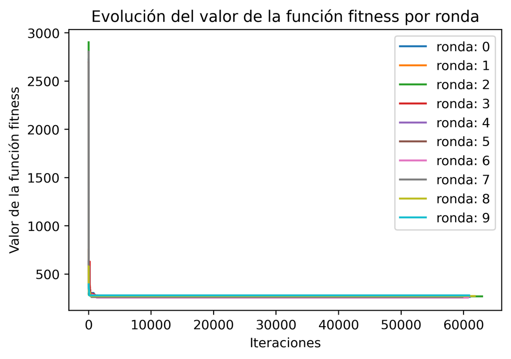

```python
import matplotlib.pyplot as plt

# Identificar el archivo con la instancia de datos
inst = 'inst_O9.txt'

dgwo = AlgLoboGris(archivo_datos=inst)
rond = 0

fig = plt.figure(dpi=400)

while rond < n_rondas:

    res_dgwo = dgwo.optimizacion_lobo_gris(tam_manada=val_mnd, n_lideres=val_ld, theta_1=val_t1,
                                           theta_2=val_t2, theta_3=val_t3, tiempo_lim=tiempo_lim)

    plt.plot(res_dgwo['vals_fitness'], label=f'ronda: {rond}')
    print(f"El mejor valor de la función fitness en la ronda {rond} fue de: {res_dgwo['vals_fitness'][-1]}")

    rond += 1

plt.xlabel('Iteraciones')
plt.ylabel('Valor de la función fitness')
plt.title('Evolución del valor de la función fitness por ronda')
plt.legend()

plt.show()
```